# Global

2024-10-25

#To find the best predictor ##First,calculate the total sales per year of the world

```r
ev_data_by_sales <- ev_data %>%
  filter(parameter == 'EV sales') %>%
  group_by(year) %>%
  summarize(total_sale_per_year = sum(value))

ev_data_by_sales
```

```
## # A tibble: 12 × 2
##     year total_sale_per_year
##    <dbl>               <dbl>
##  1  2010              17481
##  2  2011             116745
##  3  2012             285910
##  4  2013             510334
##  5  2014             810712.
##  6  2015            1412771
##  7  2016            1852523
##  8  2017            2827858
##  9  2018            4737614
## 10  2019            5180742
## 11  2020            8419233
## 12  2021           17227095
```

##Second,calculate the total electricity production of the world per year

```r
total_electricity_by_year <- energy_production %>%
  filter(Product=="Electricity") %>%
  rename("energy_production"="Value") %>%
  mutate(Time=case_when(
           str_detect(Time, '10') ~ 2010,
           str_detect(Time, '11') ~ 2011,
           str_detect(Time, '12') ~ 2012,
           str_detect(Time, '13') ~ 2013,
           str_detect(Time, '14') ~ 2014,
           str_detect(Time, '15') ~ 2015,
           str_detect(Time, '16') ~ 2016,
           str_detect(Time, '17') ~ 2017,
           str_detect(Time, '18') ~ 2018,
           str_detect(Time, '19') ~ 2019,
           str_detect(Time, '20') ~ 2020,
           str_detect(Time, '21') ~ 2021)) %>%
  group_by(Time) %>%
  summarize(total_electricity_per_year = sum(energy_production),Unit = 'GWh') %>%
  rename("year"="Time")

total_electricity_by_year
```

```
## # A tibble: 12 × 3
##     year total_electricity_per_year Unit
##    <dbl>                      <dbl> <chr>
##  1  2010                  86391757. GWh
##  2  2011                  86402242. GWh
##  3  2012                  86568680. GWh
##  4  2013                  86575452. GWh
##  5  2014                  87169040. GWh
##  6  2015                  95372732. GWh
##  7  2016                  96012816. GWh
##  8  2017                  96805695. GWh
##  9  2018                  99069376. GWh
## 10  2019                  98365721. GWh
## 11  2020                  96387049. GWh
## 12  2021                 100463459. GWh
```

##Third, calculate the total charging points of the world per year.

```r
total_charging_points_by_year <- ev_chargers %>%
  select(-category,-parameter,-unit,-mode,-...1) %>%
  rename("Country"="region") %>%
  group_by(year,powertrain) %>%
  summarize(total_charging_points_per_year = sum(value))
total_charging_points_by_year
```

```
## # A tibble: 24 × 3
## # Groups:   year [12]
##     year powertrain              total_charging_points_per_year
##    <dbl> <chr>                                            <dbl>
##  1  2010 Publicly available fast                           620
##  2  2010 Publicly available slow                         17880
##  3  2011 Publicly available fast                          1685.
##  4  2011 Publicly available slow                         27601.
##  5  2012 Publicly available fast                          3282.
##  6  2012 Publicly available slow                         81426.
##  7  2013 Publicly available fast                          6378.
##  8  2013 Publicly available slow                        122593.
##  9  2014 Publicly available fast                         28480.
## 10  2014 Publicly available slow                        237967.
## # ℹ 14 more rows
```

##Regression Modeling ###First, combine these three datasets

```r
Global_merged <- ev_data_by_sales %>%
  inner_join(total_electricity_by_year,by="year") %>%
  inner_join(total_charging_points_by_year,by="year")

Global_merged
```

```
## # A tibble: 24 × 6
##     year total_sale_per_year total_electricity_per_year Unit  powertrain
##    <dbl>               <dbl>                      <dbl> <chr> <chr>
##  1  2010              17481                   86391757. GWh   Publicly availabl…
##  2  2010              17481                   86391757. GWh   Publicly availabl…
##  3  2011             116745                   86402242. GWh   Publicly availabl…
##  4  2011             116745                   86402242. GWh   Publicly availabl…
##  5  2012             285910                   86568680. GWh   Publicly availabl…
##  6  2012             285910                   86568680. GWh   Publicly availabl…
##  7  2013             510334                   86575452. GWh   Publicly availabl…
##  8  2013             510334                   86575452. GWh   Publicly availabl…
##  9  2014             810712.                  87169040. GWh   Publicly availabl…
## 10  2014             810712.                  87169040. GWh   Publicly availabl…
## # ℹ 14 more rows
## # ℹ 1 more variable: total_charging_points_per_year <dbl>
```

##Correlation

```r
cor(Global_merged$total_sale_per_year, Global_merged$total_electricity_per_year)
```

```
## [1] 0.7073335
```

```r
cor(Global_merged$total_sale_per_year, Global_merged$total_charging_points_per_year)
```

```
## [1] 0.8308306
```

##Multi-variate linear regression

```r
model <- lm(total_sale_per_year ~ total_electricity_per_year + total_charging_points_per_year, data = Global_merged)
summary(model)
```

```
##
## Call:
## lm(formula = total_sale_per_year ~ total_electricity_per_year +
##     total_charging_points_per_year, data = Global_merged)
##
## Residuals:
##      Min       1Q   Median       3Q      Max
## -3722655 -1170484   246852   563111  9121222
##
## Coefficients:
##                                  Estimate Std. Error t value Pr(>|t|)
## (Intercept)                    -2.143e+07  1.169e+07  -1.834 0.080856 .
## total_electricity_per_year      2.446e-01  1.293e-01   1.892 0.072302 .
## total_charging_points_per_year  4.149e+00  9.606e-01   4.319 0.000303 ***
## ---
## Signif. codes:  0 '***' 0.001 '**' 0.01 '*' 0.05 '.' 0.1 ' ' 1
##
## Residual standard error: 2630000 on 21 degrees of freedom
## Multiple R-squared:  0.7354, Adjusted R-squared:  0.7102
## F-statistic: 29.18 on 2 and 21 DF,  p-value: 8.652e-07
```

*Plot*

- Maybe linear method isn’t adaptable to this case???

**Total Charging Points**

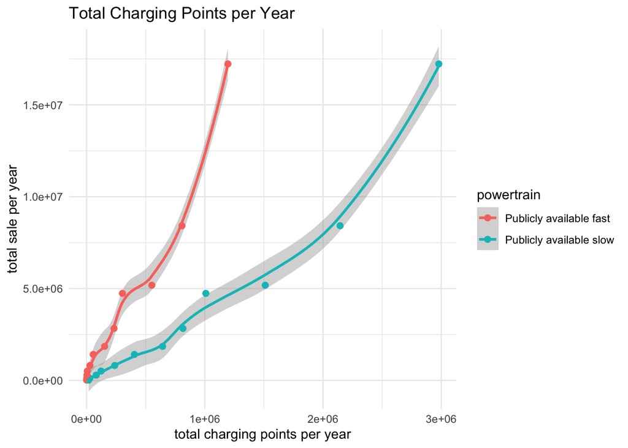

```r
Global_merged %>% ggplot(aes(y = total_sale_per_year, x = total_charging_points_per_year, color = powertrain)) +
  geom_smooth(size = 1) +
  geom_point(size = 2) +
  labs(title = "Total Charging Points per Year",
       y = "total sale per year",
       x = "total charging points per year") +
  theme_minimal()
```

**total electricity production**

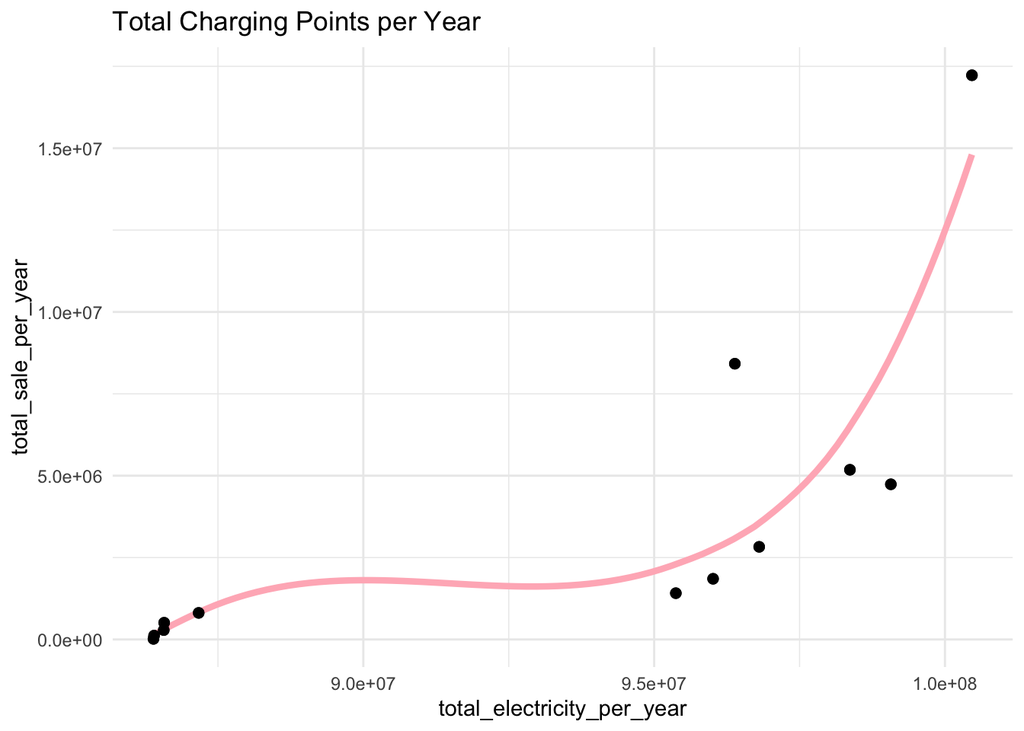

```r
Global_merged %>% ggplot(aes(y = total_sale_per_year, x = total_electricity_per_year)) +
  geom_smooth(size = 1.5,se = F,color = 'lightpink') +
  geom_point(size = 2) +
  labs(title = "Total Charging Points per Year",
       y = "total_sale_per_year",
       x = "total_electricity_per_year") +
  theme_minimal()
```

#To find the country best positioned in this transition

## electricity production

```r
total_electricity_by_country <- energy_production %>%
  filter(Product=="Electricity",!Country %in% c('OECD Total',"EA Total","OECD Europe","OECD Asia Oceania",'OECD Americas','IEA Total')) %>%
  rename("energy_production"="Value") %>%
  group_by(Country) %>%
  summarize(total_electricity_by_country = sum(energy_production),Unit = 'GWh') %>%
  arrange(desc(total_electricity_by_country)) %>%
  head(10)

total_electricity_by_country
```

```
## # A tibble: 10 × 3
##    Country                    total_electricity_by_country Unit
##    <chr>                                             <dbl> <chr>
##  1 United States                                100685475. GWh
##  2 People's Republic of China                    47212128. GWh
##  3 Japan                                         24906246. GWh
##  4 Canada                                        15404824. GWh
##  5 Germany                                       15149352. GWh
##  6 France                                        13423818. GWh
##  7 Korea                                         12820969. GWh
##  8 India                                         10013417. GWh
##  9 United Kingdom                                 8360498. GWh
## 10 Italy                                          7830575. GWh
```

##charging points

```r
total_charging_points_by_country <- ev_chargers %>%
  group_by(region) %>%
  filter(!region %in% c('World',"Europe","EU27")) %>%
  summarize(total_charging_points_by_country = sum(value)) %>%
  arrange(desc(total_charging_points_by_country)) %>%
  head(10)

total_charging_points_by_country
```

```
## # A tibble: 10 × 2
##    region         total_charging_points_by_country
##    <chr>                                     <dbl>
##  1 China                                   3183000
##  2 USA                                      508580
##  3 Netherlands                              338412
##  4 Korea                                    240720
##  5 Japan                                    210710
##  6 France                                   199399
##  7 Germany                                  180885
##  8 United Kingdom                           138616
##  9 Norway                                   103332
## 10 Canada                                    62977
```

#Finally,make a metric, showing how much electricity is available per charging point and scales it by the total EV sales, which gives you an idea of how effectively the infrastructure supports EV adoption.

$${Influence\ Metric} = \left(\frac{\text{Total Electricity
Production}}{\text{Total Charging Points}}\right) \times \text{EV Sales}$$

- Since top10 countries in EV sale, electricity production, and charging points are different, we also include Korea, India, and Italy into consideration (as a complement of top10 EV sales).
- So now we have 13 countries:China, USA, Germany, United Kingdom, France, Norway, Netherlands, Japan, Sweden, Canada,Korea, India, and Italy.

```r
US_metric <- read.csv("~/Desktop/Data Challenge/Data Challenge/CODE/Metrics/US_metric.csv")
Canada_metric <- read.csv("~/Desktop/Data Challenge/Data Challenge/CODE/Metrics/Canada_metric.csv")
China_metric <- read.csv("~/Desktop/Data Challenge/Data Challenge/CODE/Metrics/China_metric.csv")
Japan_metric <- read.csv("~/Desktop/Data Challenge/Data Challenge/CODE/Metrics/Japan_metric.csv")
UK_metric <- read.csv("~/Desktop/Data Challenge/Data Challenge/CODE/Metrics/UK_metric.csv")
France_metric <- read.csv("~/Desktop/Data Challenge/Data Challenge/CODE/Metrics/France_metric.csv")
Germany_metric <- read.csv("~/Desktop/Data Challenge/Data Challenge/CODE/Metrics/Germany_metric.csv")
Norway_metric <- read.csv("~/Desktop/Data Challenge/Data Challenge/CODE/Metrics/Norway_metric.csv")
Sweden_metric <- read.csv("~/Desktop/Data Challenge/Data Challenge/CODE/Metrics/Sweden_metric.csv")
Korea_metric <- read.csv("~/Desktop/Data Challenge/Data Challenge/CODE/Metrics/Korea_metric.csv")
India_metric <- read.csv("~/Desktop/Data Challenge/Data Challenge/CODE/Metrics/India_metric.csv")
Italy_metric <- read.csv("~/Desktop/Data Challenge/Data Challenge/CODE/Metrics/Italy_metric.csv")

df_US <- tibble(year = 2010:2021, influence_metric = US_metric$influence_metric)
df_Canada <- tibble(year = 2010:2021, influence_metric = Canada_metric$influence_metric)
df_China <- tibble(year = 2015:2021, influence_metric = China_metric$influence_metric)  # Shorter range
df_Japan <- tibble(year = 2010:2021,influence_metric = Japan_metric$influence_metric)
df_UK <- tibble(year = 2010:2021,influence_metric = UK_metric$influence_metric)
df_France <- tibble(year = 2010:2021,influence_metric = France_metric$influence_metric)
df_Germany <- tibble(year = 2010:2021,influence_metric = Germany_metric$influence_metric)
df_Netherlands <- tibble(year = 2010:2021,influence_metric = Germany_metric$influence_metric)
df_Norway <- tibble(year = 2010:2021,influence_metric = Norway_metric$influence_metric)
df_Sweden <- tibble(year = 2010:2021,influence_metric = Sweden_metric$influence_metric)
df_Korea <- tibble(year = 2010:2021,influence_metric = Korea_metric$influence_metric)
df_India <- tibble(year = 2015:2021,influence_metric = India_metric$influence_metric)
df_Italy <- tibble(year = 2010:2021,influence_metric = Italy_metric$influence_metric)


influence_metrics <- bind_rows(
  df_US %>% mutate(country = "US"),
  df_Canada %>% mutate(country = "Canada"),
  df_China %>% mutate(country = "China"),
  df_Japan %>% mutate(country = "Japan"),
  df_UK %>% mutate(country = "UK"),
  df_France %>% mutate(country = "France"),
  df_Germany %>% mutate(country = "Germany"),
  df_Netherlands %>% mutate(country = "Netherlands"),
  df_Norway %>% mutate(country = "Norway"),
  df_Sweden %>% mutate(country = "Sweden"),
  df_Korea %>% mutate(country = "Korea"),
  df_India %>% mutate(country = "India"),
  df_Italy %>% mutate(country = "Italy")
) #%>% pivot_wider(names_from = country, values_from = influence_metric)

write.csv(influence_metrics,"~/Desktop/Data Challenge/Data Challenge/CODE/Metrics/influence_metrics.csv",row.names = FALSE)
print(influence_metrics)
```

```
## # A tibble: 146 × 3
##     year influence_metric country
##    <int>            <dbl> <chr>
##  1  2010        43792104. US
##  2  2011        21371768. US
##  3  2012        22233193. US
##  4  2013        37322387. US
##  5  2014        28500110. US
##  6  2015        45548623. US
##  7  2016        53716872. US
##  8  2017        61210287. US
##  9  2018        78660583. US
## 10  2019        65760676. US
## # ℹ 136 more rows
```

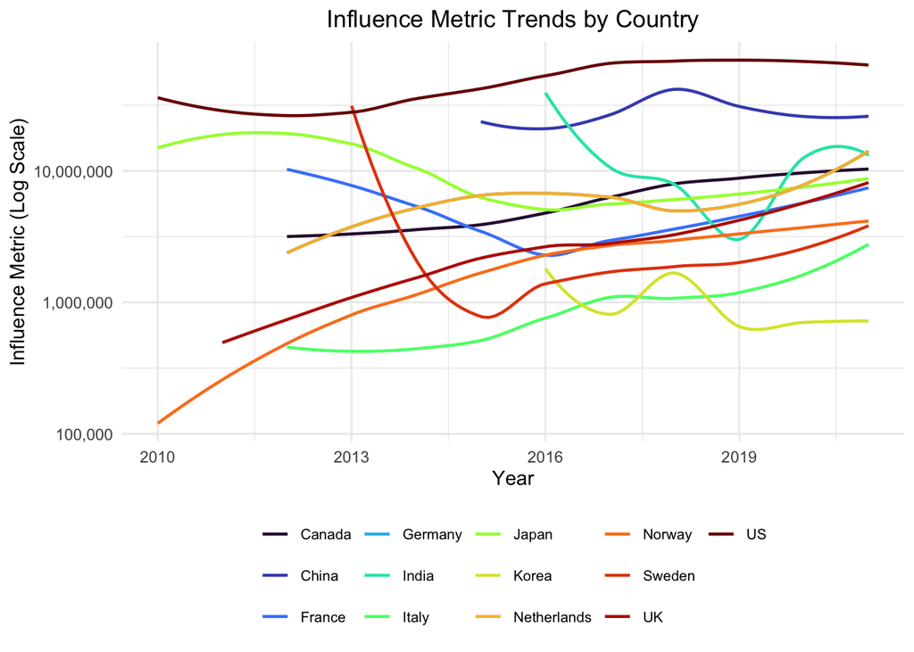

```r
ggplot(influence_metrics, aes(x = year, y = influence_metric, color = country)) +                        # Add transparency to points
  geom_smooth(se = FALSE, method = "loess", size = 0.8) + # Adjust line size
  scale_y_continuous(trans = 'log10',                  # Use a log scale for y-axis
                     labels = scales::comma) +         # Format y-axis labels
  scale_color_viridis_d(option = "H") +           # Use a distinct color palette
  theme_minimal() +
  theme(
    legend.position = "bottom",
    legend.title = element_blank(),
    legend.text = element_text(size = 8),                 # Adjust legend text size
    plot.title = element_text(hjust = 0.5)
  ) +
  labs(
    x = "Year",
    y = "Influence Metric (Log Scale)",
    title = "Influence Metric Trends by Country"
  )
```